# fin_df

## X2020_taxes

| Feature | Result |
| --- | --- |
| Variable type | numeric |
| Number of missing obs. | 537 (26.88 %) |
| Number of unique values | 536 |
| Median | 30000 |
| 1st and 3rd quartiles | 16000; 55000 |
| Min. and max. | 1; 5300000 |

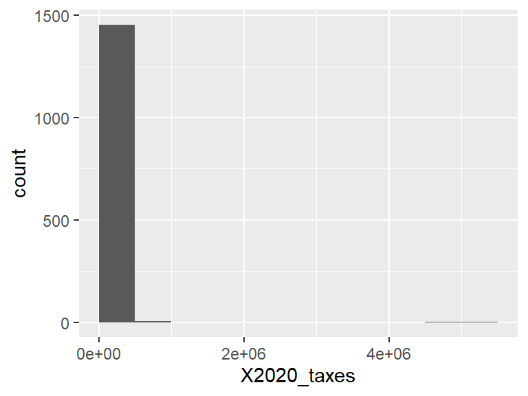

- Note that the following possible outlier values were detected: "1", "10", "120", "150", "300", …, "7e+05", "8e+05", "9e+05", "5e+06", "5300000" (31 values omitted).

## X2020_edu_exp

| Feature | Result |
| --- | --- |
| Variable type | numeric |
| Number of missing obs. | 1716 (85.89 %) |
| Number of unique values | 106 |
| Median | 1200 |
| 1st and 3rd quartiles | 18.5; 5000 |
| Min. and max. | -245; 279869 |

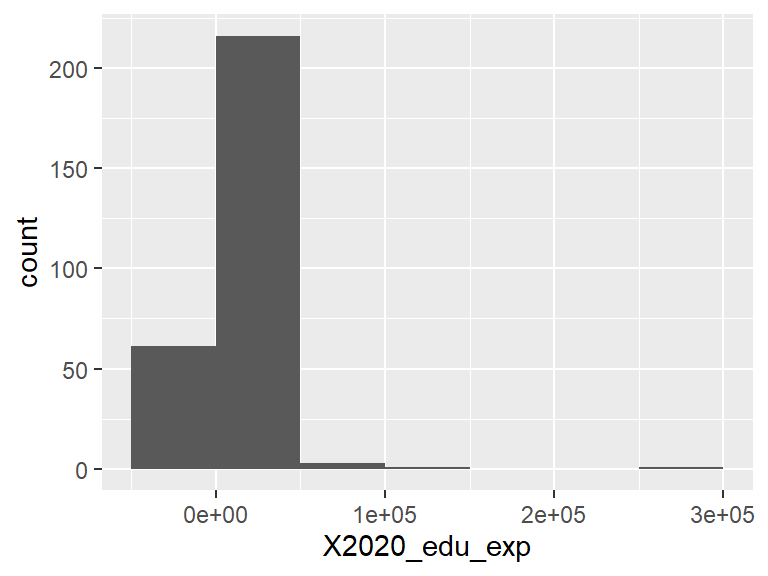

- Note that the following possible outlier values were detected: "70000", "95000", "1e+05", "150000", "279869".

## X2020_other_exp

| Feature | Result |
| --- | --- |
| Variable type | numeric |
| Number of missing obs. | 1817 (90.94 %) |
| Number of unique values | 95 |
| Median | 2500 |
| 1st and 3rd quartiles | 1; 8200 |
| Min. and max. | 0; 170000 |

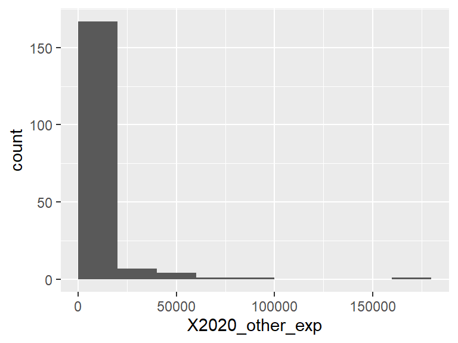

- Note that the following possible outlier values were detected: "67165", "1e+05", "170000".

Report generation information:

- Created by: Vishwanath Guruvayur (username: `vishg`).
- Report creation time: Tue Jul 30 2024 23:32:04
- Report was run from directory: `C:/Users/vishg/Documents/MSDS/STAT6021 - Linear Models for Data Science/financial_independence/codes`
- dataMaid v1.4.1 [Pkg: 2021-10-08 from CRAN (R 4.4.1)]
- R version 4.4.0 (2024-04-24 ucrt).
- Platform: x86_64-w64-mingw32/x64(America/New_York).
- Function call: `makeDataReport(data = fin_df, output = "html", replace = T)`